# Project: Investigate a Dataset - [Scheduled Hospital Visitation in Brazil]

- Introduction
- Data Wrangling
- Exploratory Data Analysis
- Conclusions

## Introduction

### Dataset Description

This dataset collects information from 100k medical appointments in Brazil and is focused on the question of whether or not patients show up for their appointment. A number of characteristics about the patient are included in each row. Dataset column attributes and decriptions include:

### Attributes and Description

1. PatientId: Unique way to identify a patient.
2. AppointmentID: Identification of each appointment.
3. Gender: Sex of patient either Male or Female.
4. ScheduledDay: Day a patient picks to visit the hospital.
5. AppointmentDay:Day a patient is to visit the hospital.
6. Age: How old is the patient.
7. Neighbourhood: Location of the hospital or actual place for appointment.
8. Scholarship: True or False . Indicates whether or not the patient is enrolled in Brasilian welfare program Bolsa Família.
9. Hipertension: True or False.
10. Diabetes: True or False.
11. Alcoholism: True or False.
12. Handcap: True or False.
13. SMS_received: whether patient received SMS or not. Received or Not_received.
14. No-show: Yes or No. No implying the patient showed for their apppointment while Yes imply they did not.

**Male** = M, **Female** = F, **True** = 1, **False** = 0, **Received** = 1, **Not_received** = 0

### Question(s) for Analysis

1. Percentage of patients that shows up for appointments ?
2. Which patient gender will show up more for appointments ?
3. Does SMS_reminders helps patient show up for their appointments ?

```python
import pandas as pd
```

```python
from subprocess import call
call(['python', '-m', 'nbconvert', 'Investigate_a_Dataset.ipynb'])
```

```
0
```

```python
cd Database_No_show_appointments
```

```
/home/workspace/Database_No_show_appointments
```

```python
# Import necessary packages
import pandas as pd
import numpy as np
import matplotlib.pyplot as plt
import seaborn as sns
% matplotlib inline
```

```python
# Upgrade pandas to use dataframe.explode() function.
!pip install --upgrade pandas==0.25.0
```

## Data Wrangling

> **Tip**: In this section of the report, you will load in the data, check for cleanliness, and then trim and clean your dataset for analysis. Make sure that you **document your data cleaning steps in mark-down cells precisely and justify your cleaning decisions.**

#### Load Data

```python
# Load noshowappointments dataset and print out 5 lines
df=pd.read_csv('noshowappointments-kagglev2-may-2016.csv')
df.head(5)
```

|  | PatientId | AppointmentID | Gender | ScheduledDay | AppointmentDay | Age | Neighbourhood | Scholarship | Hipertension | Diabetes | Alcoholism | Handcap | SMS_received | No-show |
| --- | --- | --- | --- | --- | --- | --- | --- | --- | --- | --- | --- | --- | --- | --- |
| 0 | 2.987250e+13 | 5642903 | F | 2016-04-29T18:38:08Z | 2016-04-29T00:00:00Z | 62 | JARDIM DA PENHA | 0 | 1 | 0 | 0 | 0 | 0 | No |
| 1 | 5.589978e+14 | 5642503 | M | 2016-04-29T16:08:27Z | 2016-04-29T00:00:00Z | 56 | JARDIM DA PENHA | 0 | 0 | 0 | 0 | 0 | 0 | No |
| 2 | 4.262962e+12 | 5642549 | F | 2016-04-29T16:19:04Z | 2016-04-29T00:00:00Z | 62 | MATA DA PRAIA | 0 | 0 | 0 | 0 | 0 | 0 | No |
| 3 | 8.679512e+11 | 5642828 | F | 2016-04-29T17:29:31Z | 2016-04-29T00:00:00Z | 8 | PONTAL DE CAMBURI | 0 | 0 | 0 | 0 | 0 | 0 | No |
| 4 | 8.841186e+12 | 5642494 | F | 2016-04-29T16:07:23Z | 2016-04-29T00:00:00Z | 56 | JARDIM DA PENHA | 0 | 1 | 1 | 0 | 0 | 0 | No |

```python
# View a concise summary of the dataset
df.info()
```

```
<class 'pandas.core.frame.DataFrame'>
RangeIndex: 110527 entries, 0 to 110526
Data columns (total 14 columns):
PatientId         110527 non-null float64
AppointmentID     110527 non-null int64
Gender            110527 non-null object
ScheduledDay      110527 non-null object
AppointmentDay    110527 non-null object
Age               110527 non-null int64
Neighbourhood     110527 non-null object
Scholarship       110527 non-null int64
Hipertension      110527 non-null int64
Diabetes          110527 non-null int64
Alcoholism        110527 non-null int64
Handcap           110527 non-null int64
SMS_received      110527 non-null int64
No-show           110527 non-null object
dtypes: float64(1), int64(8), object(5)
memory usage: 11.8+ MB
```

#### Accessing Data

```python
#explore data
df.tail(6)
```

|  | PatientId | AppointmentID | Gender | ScheduledDay | AppointmentDay | Age | Neighbourhood | Scholarship | Hipertension | Diabetes | Alcoholism | Handcap | SMS_received | No-show |
| --- | --- | --- | --- | --- | --- | --- | --- | --- | --- | --- | --- | --- | --- | --- |
| 110521 | 3.635534e+13 | 5651072 | F | 2016-05-03T08:23:40Z | 2016-06-07T00:00:00Z | 53 | MARIA ORTIZ | 0 | 0 | 0 | 0 | 0 | 1 | No |
| 110522 | 2.572134e+12 | 5651768 | F | 2016-05-03T09:15:35Z | 2016-06-07T00:00:00Z | 56 | MARIA ORTIZ | 0 | 0 | 0 | 0 | 0 | 1 | No |
| 110523 | 3.596266e+12 | 5650093 | F | 2016-05-03T07:27:33Z | 2016-06-07T00:00:00Z | 51 | MARIA ORTIZ | 0 | 0 | 0 | 0 | 0 | 1 | No |
| 110524 | 1.557663e+13 | 5630692 | F | 2016-04-27T16:03:52Z | 2016-06-07T00:00:00Z | 21 | MARIA ORTIZ | 0 | 0 | 0 | 0 | 0 | 1 | No |
| 110525 | 9.213493e+13 | 5630323 | F | 2016-04-27T15:09:23Z | 2016-06-07T00:00:00Z | 38 | MARIA ORTIZ | 0 | 0 | 0 | 0 | 0 | 1 | No |
| 110526 | 3.775115e+14 | 5629448 | F | 2016-04-27T13:30:56Z | 2016-06-07T00:00:00Z | 54 | MARIA ORTIZ | 0 | 0 | 0 | 0 | 0 | 1 | No |

```python
#check sample size and no of column
df.shape
```

```
(110527, 14)
```

```python
#check column names
df.columns
```

```
Index(['PatientId', 'AppointmentID', 'Gender', 'ScheduledDay',
       'AppointmentDay', 'Age', 'Neighbourhood', 'Scholarship', 'Hipertension',
       'Diabetes', 'Alcoholism', 'Handcap', 'SMS_received', 'No-show'],
      dtype='object')
```

```python
#Check for duplicated data
df.duplicated().sum().any()
```

```
False
```

```python
# check for null values
df.isnull().sum().any()
```

```
False
```

```python
#check for the data types
df.dtypes
```

```
PatientId         float64
AppointmentID       int64
Gender             object
ScheduledDay       object
AppointmentDay     object
Age                 int64
Neighbourhood      object
Scholarship         int64
Hipertension        int64
Diabetes            int64
Alcoholism          int64
Handcap             int64
SMS_received        int64
No-show            object
dtype: object
```

```python
# Check for the number of unique value in each column
df.nunique()
```

```
PatientId          62299
AppointmentID     110527
Gender                 2
ScheduledDay      103549
AppointmentDay        27
Age                  104
Neighbourhood         81
Scholarship            2
Hipertension           2
Diabetes               2
Alcoholism             2
Handcap                5
SMS_received           2
No-show                2
dtype: int64
```

```python
# summary statistics of the data
df.describe()
```

|  | PatientId | AppointmentID | Age | Scholarship | Hipertension | Diabetes | Alcoholism | Handcap | SMS_received |
| --- | --- | --- | --- | --- | --- | --- | --- | --- | --- |
| count | 1.105270e+05 | 1.105270e+05 | 110527.000000 | 110527.000000 | 110527.000000 | 110527.000000 | 110527.000000 | 110527.000000 | 110527.000000 |
| mean | 1.474963e+14 | 5.675305e+06 | 37.088874 | 0.098266 | 0.197246 | 0.071865 | 0.030400 | 0.022248 | 0.321026 |
| std | 2.560949e+14 | 7.129575e+04 | 23.110205 | 0.297675 | 0.397921 | 0.258265 | 0.171686 | 0.161543 | 0.466873 |
| min | 3.921784e+04 | 5.030230e+06 | -1.000000 | 0.000000 | 0.000000 | 0.000000 | 0.000000 | 0.000000 | 0.000000 |
| 25% | 4.172614e+12 | 5.640286e+06 | 18.000000 | 0.000000 | 0.000000 | 0.000000 | 0.000000 | 0.000000 | 0.000000 |
| 50% | 3.173184e+13 | 5.680573e+06 | 37.000000 | 0.000000 | 0.000000 | 0.000000 | 0.000000 | 0.000000 | 0.000000 |
| 75% | 9.439172e+13 | 5.725524e+06 | 55.000000 | 0.000000 | 0.000000 | 0.000000 | 0.000000 | 0.000000 | 1.000000 |
| max | 9.999816e+14 | 5.790484e+06 | 115.000000 | 1.000000 | 1.000000 | 1.000000 | 1.000000 | 4.000000 | 1.000000 |

### Data Cleaning

1. Dropping columns not necessary for the analysis. 2. Rename column names to more intuitive and appropriate names. 3. Convert all column names to lower case for consistency. 4. Change value names(quantitative variables) to more intuitive names(categorical variables). 5. Datetime formatting. 6. Delete rows with inappropriate values e.g Age with a minimum value of -1.

```python
# Drop columns not necessary for the analysis
df.drop(['PatientId', 'AppointmentID', 'Handcap'], axis=1, inplace=True)
```

```python
#confirm drop changes
df.columns
```

```
Index(['Gender', 'ScheduledDay', 'AppointmentDay', 'Age', 'Neighbourhood',
       'Scholarship', 'Hipertension', 'Diabetes', 'Alcoholism', 'SMS_received',
       'No-show'],
      dtype='object')
```

```python
#Renaming column names
df = df.rename(columns={'Hipertension' : 'Hypertension','Scholarship': 'BolsaFamília','No-show': 'Appointment', 'SMS_received': 'SMS'})
```

```python
#confirm changes
df.columns
```

```
Index(['Gender', 'ScheduledDay', 'AppointmentDay', 'Age', 'Neighbourhood',
       'BolsaFamília', 'Hypertension', 'Diabetes', 'Alcoholism', 'SMS',
       'Appointment'],
      dtype='object')
```

```python
# The lambda function will be employed to avoid repetition
# convert all column names to lower case for consistency
df.rename(columns = lambda x : x.lower(), inplace=True)
df.head(0)
```

|  | gender | scheduledday | appointmentday | age | neighbourhood | bolsafamília | hypertension | diabetes | alcoholism | sms | appointment |
| --- | --- | --- | --- | --- | --- | --- | --- | --- | --- | --- | --- |

```python
#change quantitative values in columns to more intuitive names(categorical variables)
df['hypertension'] = df['hypertension'].replace([0,1],['Not_HTN', 'HTN'])
df['diabetes'] = df['diabetes'].replace([0,1],['Not_DM', 'DM'])
df['alcoholism'] = df['alcoholism'].replace([0,1],['Not_Alcoholic', 'Alcoholic'])
df['bolsafamília'] = df['bolsafamília'].replace([0,1],['Not_Enrolled', 'Enrolled'])
df['sms'] = df['sms'].replace([0,1],['Not_Received', 'Received'])
```

```python
#confirm changes
df.head()
```

|  | gender | scheduledday | appointmentday | age | neighbourhood | bolsafamília | hypertension | diabetes | alcoholism | sms | appointment |
| --- | --- | --- | --- | --- | --- | --- | --- | --- | --- | --- | --- |
| 0 | F | 2016-04-29T18:38:08Z | 2016-04-29T00:00:00Z | 62 | JARDIM DA PENHA | Not_Enrolled | HTN | Not_DM | Not_Alcoholic | Not_Received | No |
| 1 | M | 2016-04-29T16:08:27Z | 2016-04-29T00:00:00Z | 56 | JARDIM DA PENHA | Not_Enrolled | Not_HTN | Not_DM | Not_Alcoholic | Not_Received | No |
| 2 | F | 2016-04-29T16:19:04Z | 2016-04-29T00:00:00Z | 62 | MATA DA PRAIA | Not_Enrolled | Not_HTN | Not_DM | Not_Alcoholic | Not_Received | No |
| 3 | F | 2016-04-29T17:29:31Z | 2016-04-29T00:00:00Z | 8 | PONTAL DE CAMBURI | Not_Enrolled | Not_HTN | Not_DM | Not_Alcoholic | Not_Received | No |
| 4 | F | 2016-04-29T16:07:23Z | 2016-04-29T00:00:00Z | 56 | JARDIM DA PENHA | Not_Enrolled | HTN | DM | Not_Alcoholic | Not_Received | No |

```python
# change the 'No' and 'Yes' to more intuitive names(categorical variables)
df['appointment'] = df['appointment'].replace(['No', 'Yes'],['show','Not_show'])
```

```python
#confirm changes
df['appointment'].unique()
```

```
array(['show', 'Not_show'], dtype=object)
```

```python
#Datetime formatting
#Introducing lambda to remove time value as is not necessary for this analysis
df[['scheduledday','appointmentday']] = df[['scheduledday','appointmentday']].astype('datetime64[ns]')
```

```python
#confirm changes
df[['scheduledday','appointmentday']].dtypes
```

```
scheduledday      datetime64[ns]
appointmentday    datetime64[ns]
dtype: object
```

```python
#Delete rows with wrong values(age < 0)
wrong_age =df.query('age =="-1"').index
```

```python
df.drop(wrong_age,axis=0, inplace=True)
```

```python
#confirm for roll with age < 0
df.query('age =="-1"')
```

|  | gender | scheduledday | appointmentday | age | neighbourhood | bolsafamília | hypertension | diabetes | alcoholism | sms | appointment |
| --- | --- | --- | --- | --- | --- | --- | --- | --- | --- | --- | --- |

```python
#check min age to confirm if row with inappropiate value is removed
df.age.min()
```

```
0
```

## Exploratory Data Analysis

### Research Question 1 (Percentage of patients that shows up for appointment)

```python
# percentage of patients that showed up for appointment
percentage_count = df['appointment'].value_counts()/df['appointment'].count()*100
percentage_count.round(1)
```

```
show        79.8
Not_show    20.2
Name: appointment, dtype: float64
```

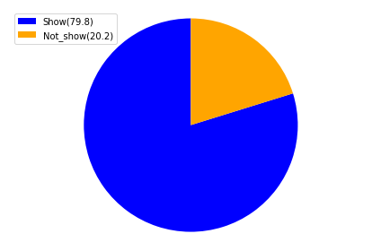

```python
#chart labels
labels = [r'Show(79.8)', r'Not_show(20.2)']
sizes = [79.8, 20.2]
colors =['blue', 'orange']
patches, texts = plt.pie(sizes, colors=colors, startangle=90)
plt.legend()
plt.legend(patches, labels, loc="best")

# Set aspect ratio to be equal so that pie is drawn as a circle.
plt.axis('equal')
plt.tight_layout()
plt.show()
```

##### Approximately only 80% of the patients showed up for their scheduled appointment.

### Research Question 2 (Which patients gender will show up more for scheduled appointment)

```python
# percentage of the patients by gender
gender_percentage = df['gender'].value_counts()/df['gender'].count()*100
gender_percentage.round(2)
```

```
F    65.0
M    35.0
Name: gender, dtype: float64
```

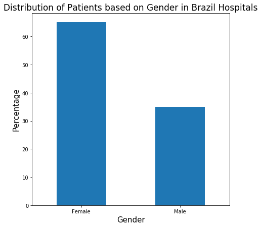

```python
# Explore gender distibution
gender_percentage.plot(kind='bar', figsize=(7,7));

# chart labels
plt.xlabel('Gender', fontsize=15);
plt.ylabel('Percentage', fontsize=15)
plt.title('Distribution of Patients based on Gender in Brazil Hospitals', fontsize=17);
location = [0,1]
labels = ['Female', 'Male']
plt.xticks(location, labels, rotation=0);
```

```python
# calculate the percentage of patients who showed up and not based on gender
gender_percentage = df.groupby(['gender', 'appointment'])['age'].count()/df.groupby(['gender'])['age'].count()*100
gender_percentage.round(2)
```

```
gender  appointment
F       Not_show       20.31
        show           79.69
M       Not_show       19.97
        show           80.03
Name: age, dtype: float64
```

```python
#Create a function to plot bar chart in other to acoid repetition
def bar(data, xaxis, yaxis, titles, labels):
    data.plot(kind = 'bar', figsize =(8,8))
    plt.xlabel(xaxis, fontsize = 15)
    plt.ylabel(yaxis, fontsize = 15)
    plt.title(titles, fontsize = 15)
    location = [0,1]
    labels = labels
    plt.xticks(location, labels, rotation = 0)
    plt.show()
```

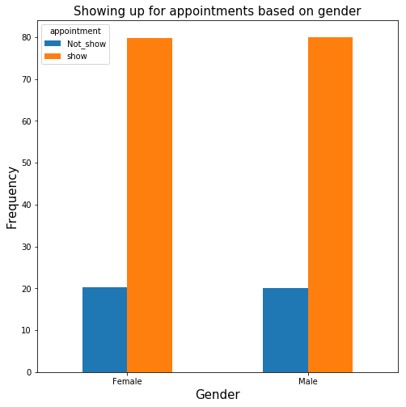

```python
# Double bar chart showing patient those who showed up and not based on gender
# Using the bar function created to avoid repetition
bar(gender_percentage.unstack(), 'Gender', 'Frequency', 'Showing up for appointments based on gender', labels)
```

### Research Question 3 (Does SMS_reminders helps patient show up for their appointments )

```python
# Percentage of patients that received sms
percentage_sms = df['sms'].value_counts()/df['sms'].count()*100
percentage_sms.round(2)
```

```
Not_Received    67.9
Received        32.1
Name: sms, dtype: float64
```

```python
# Percentage of all patients that received SMS and showed up
percentage_sms_received = df.groupby(['sms', 'appointment'])['age'].count()/df.groupby(['sms'])['age'].count()*100
percentage_sms_received.unstack().round(1)
```

| appointment sms | Not_show | show |
| --- | --- | --- |
| Not_Received | 16.7 | 83.3 |
| Received | 27.6 | 72.4 |

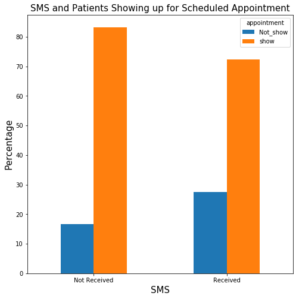

```python
# Double bar to show percentage of patients that received and did not received sms and how they responded to their medical appointments
labels = ['Not Received', 'Received']
bar(percentage_sms_received.unstack(), 'SMS', 'Percentage', 'SMS and Patients Showing up for Scheduled Appointment', labels)
```

## Conclusions

#### **Summary**

1. Approximately 80% for patients showed up for their scheduld appointment. 2. Majority of the patients are female, yet based on percentage distribution, approximately same percenatage of male and female gender show up for their medical appointments. 3. Receiving sms did not really contribute tp patients showing up or not for their medical appointments.

#### **Limitations**

1. Indequate information on why only a small percentage of the population received sms.

#### **Recommendation**

A random sampling method should be employed for adequate distribution of the sample size, as from this dataset there was a higher number of females than male. Comparison would be made adequately using proportion or percentage

```python
df.to_csv('df_final.csv')
```